# outcome_var_prep

2026-08-28

# Deservingness Scores

## Sympathy “desor_core” control

raw_alpha: 0.9078 and 0.9142 internal consistency – suggests items hang together well. average_r = 0.5422 – high inter-item correlation. cor: fairly strong correlation to the DV (0.547) R^2 = 0.30 bivariately. Soaks up general generosity toward assistance-framed groups. Should justify use of control for testing whether contact predicts deservingness of incarcerated people, above and beyond that general orientation.

# Policy Preferences

## Dpen & LWOP

Takeaway: prison pen, prison pen 1 = dpen, prison pen 5 = lwop now -confirmed that prisonpen works – constructed with average of death penalty and lwop. USE dpen_rev and lwop_rev and prisonpen.

### CBA & Corr

```
                   d_welfare_tanf_abc d_fstamps_snap_abc d_medicaid_abc d_medicare_abc
d_welfare_tanf_abc               2197               2186           2184           2185
d_fstamps_snap_abc               2186               2199           2188           2187
d_medicaid_abc                   2184               2188           2200           2190
d_medicare_abc                   2185               2187           2190           2198
d_unemployed_abc                 2186               2191           2185           2184
d_poorfam_abc                    2186               2191           2188           2187
d_homeless_abc                   2187               2193           2192           2189
d_immigrants_abc                 2184               2185           2182           2182
d_unauth_undoc_abc               2188               2193           2189           2188
                   d_unemployed_abc d_poorfam_abc d_homeless_abc d_immigrants_abc
d_welfare_tanf_abc             2186          2186           2187             2184
d_fstamps_snap_abc             2191          2191           2193             2185
d_medicaid_abc                 2185          2188           2192             2182
d_medicare_abc                 2184          2187           2189             2182
d_unemployed_abc               2199          2192           2193             2184
d_poorfam_abc                  2192          2202           2196             2188
d_homeless_abc                 2193          2196           2205             2187
d_immigrants_abc               2184          2188           2187             2195
d_unauth_undoc_abc             2190          2193           2196             2188
                   d_unauth_undoc_abc
d_welfare_tanf_abc               2188
d_fstamps_snap_abc               2193
d_medicaid_abc                   2189
d_medicare_abc                   2188
d_unemployed_abc                 2190
d_poorfam_abc                    2193
d_homeless_abc                   2196
d_immigrants_abc                 2188
d_unauth_undoc_abc               2207
```

results - The **correlation** between the two items is **r = 0.238**.

- With only two items, Cronbach’s alpha is essentially a rescaled version of that correlation. (So don’t oversell alpha here; the correlation is the clean summary.)

Interpretation

- **These two punitive items are positively related, but weakly so.** People who favor the death penalty are *somewhat* more likely to favor LWOP, but plenty of respondents don’t treat them as interchangeable.
- That’s not necessarily a “problem.” Death penalty and LWOP are conceptually related (punitive severity), but they can tap **different moral/legal intuitions** (irreversibility, innocence risk, retribution vs incapacitation), so moderate association is plausible.
- The response distribution shows a **nontrivial chunk of “Don’t know”** recoded to 2.5 (15–17%) and about **8% missing** for each item. The DK-to-midpoint choice can slightly inflate apparent consistency by shrinking variance, so reliability is a conservative-ish check but not definitive.

### Visual

```
core_keep
FALSE  TRUE
   16  2206
[1] 0.907757
[1] 0.9142186
[1] 0.5421604
NULL
```

|  | raw_alpha | std.alpha | G6(smc) | average_r | S/N | alpha se | var.r | med.r |
| --- | --- | --- | --- | --- | --- | --- | --- | --- |
| d_welfare_tanf_abc | 0.8896849 | 0.8982261 | 0.9044350 | 0.5245368 | 8.825698 | 0.003641870 | 0.016620702 | 0.5530978 |
| d_fstamps_snap_abc | 0.8899453 | 0.8976559 | 0.9035589 | 0.5229850 | 8.770960 | 0.003616007 | 0.015190662 | 0.5322672 |
| d_medicaid_abc | 0.8938124 | 0.9002473 | 0.9060195 | 0.5300970 | 9.024791 | 0.003475945 | 0.015527326 | 0.5322672 |
| d_medicare_abc | 0.9010439 | 0.9078890 | 0.9121638 | 0.5519831 | 9.856469 | 0.003258558 | 0.014325501 | 0.5972843 |
| d_unemployed_abc | 0.8941940 | 0.9021911 | 0.9110383 | 0.5355324 | 9.224023 | 0.003491126 | 0.018179375 | 0.5591105 |
| d_poorfam_abc | 0.8953724 | 0.9019418 | 0.9078726 | 0.5348303 | 9.198026 | 0.003430565 | 0.015630754 | 0.5322672 |
| d_homeless_abc | 0.8943798 | 0.9022717 | 0.9097446 | 0.5357595 | 9.232446 | 0.003479995 | 0.017593723 | 0.5591105 |
| d_immigrants_abc | 0.9019390 | 0.9103170 | 0.9116990 | 0.5592379 | 10.150381 | 0.003227340 | 0.017893487 | 0.5979981 |
| d_unauth_undoc_abc | 0.9158933 | 0.9183877 | 0.9162344 | 0.5844815 | 11.253052 | 0.002718788 | 0.008187682 | 0.5979981 |

|  | n | raw.r | std.r | r.cor | r.drop | mean | sd |
| --- | --- | --- | --- | --- | --- | --- | --- |
| d_welfare_tanf_abc | 2191 | 0.8403129 | 0.8412839 | 0.8275323 | 0.7893962 | 64.61524 | 25.43031 |
| d_fstamps_snap_abc | 2198 | 0.8405292 | 0.8475532 | 0.8368280 | 0.7915936 | 69.79481 | 24.26326 |
| d_medicaid_abc | 2194 | 0.8021491 | 0.8188208 | 0.7995767 | 0.7474285 | 72.63856 | 22.31445 |
| d_medicare_abc | 2194 | 0.7092337 | 0.7304020 | 0.6914638 | 0.6345065 | 76.50000 | 22.02996 |
| d_unemployed_abc | 2196 | 0.7928828 | 0.7968620 | 0.7626254 | 0.7297212 | 65.52960 | 24.88180 |
| d_poorfam_abc | 2198 | 0.7824723 | 0.7996984 | 0.7749191 | 0.7245053 | 76.54004 | 22.10819 |
| d_homeless_abc | 2200 | 0.7914117 | 0.7959448 | 0.7649288 | 0.7268861 | 69.76000 | 24.99573 |
| d_immigrants_abc | 2190 | 0.7219752 | 0.7010929 | 0.6540620 | 0.6306868 | 61.69224 | 27.71938 |
| d_unauth_undoc_abc | 2198 | 0.6378031 | 0.5991101 | 0.5399721 | 0.5059482 | 43.84213 | 32.33286 |

```
[[1]]
[1] "d_welfare_tanf_abc" "d_fstamps_snap_abc" "d_medicaid_abc"     "d_medicare_abc"
[5] "d_unemployed_abc"   "d_poorfam_abc"      "d_homeless_abc"     "d_immigrants_abc"
[9] "d_unauth_undoc_abc"
```

## Prison Help

### Descriptive

```
   Min. 1st Qu.  Median    Mean 3rd Qu.    Max.     NAs
   0.00   52.22   66.67   66.75   81.11  100.00      16
     Min.   1st Qu.    Median      Mean   3rd Qu.      Max.       NAs
-3.476078 -0.756474 -0.004244  0.000000  0.747987  1.731673        16
```

### CBA & Corr

```
   Min. 1st Qu.  Median    Mean 3rd Qu.    Max.     NAs
  1.000   2.000   4.000   3.919   5.000   7.000     190
```

## Election Items

Come out of above block with: post_felony_vote_rev individual item, 1–3 jail_access_rev individual item, 1–3 incarc_electoral_mean combined measure, 1–3

post_felony_vote_rev_1_to_4 comparable item, 1–4 jail_access_rev_1_to_4 comparable item, 1–4 incarc_electoral_mean_1_to_4 comparable combined measure, 1–4

#### D.4_C Prison/Election Items Descriptive look

What’s up

###CBA & Corr: JBV & RR

```
          dpen_rev  lwop_rev
dpen_rev 1.0000000 0.2384755
lwop_rev 0.2384755 1.0000000
Call:psych::corr.test(x = pen_data)
Correlation matrix
         dpen_rev lwop_rev
dpen_rev     1.00     0.24
lwop_rev     0.24     1.00
Sample Size
[1] 2036
Probability values (Entries above the diagonal are adjusted for multiple tests.)
         dpen_rev lwop_rev
dpen_rev        0        0
lwop_rev        0        0

 To see confidence intervals of the correlations, print with the short=FALSE option

Reliability analysis
Call: psych::alpha(x = pen_data)

  raw_alpha std.alpha G6(smc) average_r  S/N   ase mean   sd median_r
      0.38      0.39    0.24      0.24 0.63 0.026  2.8 0.71     0.24

    95% confidence boundaries
         lower alpha upper
Feldt     0.33  0.38  0.43
Duhachek  0.33  0.38  0.43

 Reliability if an item is dropped:
         raw_alpha std.alpha G6(smc) average_r  S/N alpha se var.r med.r
dpen_rev      0.28      0.24   0.057      0.24 0.31       NA     0  0.24
lwop_rev      0.21      0.24   0.057      0.24 0.31       NA     0  0.24

 Item statistics
            n raw.r std.r r.cor r.drop mean   sd
dpen_rev 2036  0.82  0.79  0.38   0.24  2.8 0.96
lwop_rev 2036  0.75  0.79  0.38   0.24  2.9 0.83

Non missing response frequency for each item
            1    2  2.5    3    4 miss
dpen_rev 0.13 0.17 0.15 0.30 0.26 0.08
lwop_rev 0.06 0.14 0.17 0.36 0.28 0.08
```

|  | vars | n | mean | sd | median | trimmed | mad | min | max | range | skew | kurtosis | se |
| --- | --- | --- | --- | --- | --- | --- | --- | --- | --- | --- | --- | --- | --- |
| dpen_rev | 1 | 2036 | 2.76 | 0.96 | 3 | 2.83 | 1.48 | 1 | 4 | 3 | -0.32 | -0.77 | 0.02 |
| lwop_rev | 2 | 2036 | 2.94 | 0.83 | 3 | 3.00 | 0.74 | 1 | 4 | 3 | -0.40 | -0.27 | 0.02 |

```
          dpen_rev  lwop_rev
dpen_rev 1.0000000 0.2384755
lwop_rev 0.2384755 1.0000000

Reliability analysis
Call: psych::alpha(x = pen_data, check.keys = FALSE)
```

|  | raw_alpha | std.alpha | G6(smc) | average_r | S/N | ase | mean | sd | median_r |
| --- | --- | --- | --- | --- | --- | --- | --- | --- | --- |
|  | 0.3817432 | 0.3851114 | 0.2384755 | 0.2384755 | 0.6263109 | 0.02593137 | 2.849337 | 0.7082253 | 0.2384755 |

```
    95% confidence boundaries
```

|  | lower | alpha | upper |
| --- | --- | --- | --- |
| Feldt | 0.33 | 0.38 | 0.43 |
| Duhachek | 0.33 | 0.38 | 0.43 |

```
 Reliability if an item is dropped:
```

|  | raw_alpha | std.alpha | G6(smc) | average_r | S/N | alpha se | var.r | med.r |
| --- | --- | --- | --- | --- | --- | --- | --- | --- |
| dpen_rev | 0.2764327 | 0.2384755 | 0.05687059 | 0.2384755 | 0.3131555 | NA | 0 | 0.2384755 |
| lwop_rev | 0.2057303 | 0.2384755 | 0.05687059 | 0.2384755 | 0.3131555 | NA | 0 | 0.2384755 |

```
 Item statistics
```

|  | n | raw.r | std.r | r.cor | r.drop | mean | sd |
| --- | --- | --- | --- | --- | --- | --- | --- |
| dpen_rev | 2036 | 0.8212146 | 0.7869166 | 0.3842825 | 0.2384755 | 2.761051 | 0.9647348 |
| lwop_rev | 2036 | 0.7499958 | 0.7869166 | 0.3842825 | 0.2384755 | 2.937623 | 0.8322664 |

```
Non missing response frequency for each item
            1    2  2.5    3    4 miss
dpen_rev 0.13 0.17 0.15 0.30 0.26 0.08
lwop_rev 0.06 0.14 0.17 0.36 0.28 0.08
   Min. 1st Qu.  Median    Mean 3rd Qu.    Max.     NAs
  1.000   2.000   3.000   2.761   4.000   4.000     186
   Min. 1st Qu.  Median    Mean 3rd Qu.    Max.     NAs
  1.000   2.500   3.000   2.938   4.000   4.000     186
```

###CBA & Corr: Help, JBV & RR

Need

post_felony_vote_rev jail_access_rev_1_to_4 q25_help_data or min_wage, free_calls, ed_funds, alt_sentencing

#### D5. Variance and Stand Dev

# Write and Save Data

```
   Min. 1st Qu.  Median    Mean 3rd Qu.    Max.     NAs
  1.000   2.500   2.875   2.880   3.250   4.000     186
   Min. 1st Qu.  Median    Mean 3rd Qu.    Max.     NAs
  1.000   2.500   3.000   2.825   3.000   4.000     187
```

|  | vars | n | mean | sd | median | trimmed | mad | min | max | range | skew | kurtosis | se |
| --- | --- | --- | --- | --- | --- | --- | --- | --- | --- | --- | --- | --- | --- |
| min_wage | 1 | 2036 | 2.69 | 0.95 | 3 | 2.74 | 1.48 | 1 | 4 | 3 | -0.24 | -0.78 | 0.02 |
| free_calls | 2 | 2036 | 2.86 | 0.93 | 3 | 2.95 | 1.48 | 1 | 4 | 3 | -0.42 | -0.63 | 0.02 |
| ed_funds | 3 | 2035 | 3.14 | 0.83 | 3 | 3.25 | 1.48 | 1 | 4 | 3 | -0.78 | 0.18 | 0.02 |
| alt_sentencing | 4 | 2035 | 2.82 | 0.80 | 3 | 2.87 | 0.74 | 1 | 4 | 3 | -0.37 | 0.00 | 0.02 |

```
$breaks
 [1] 1.0 1.2 1.4 1.6 1.8 2.0 2.2 2.4 2.6 2.8 3.0 3.2 3.4 3.6 3.8 4.0

$counts
 [1] 274   0   0   0 421   0   0 238   0 647   0   0   0   0 456

$density
 [1] 0.6728880 0.0000000 0.0000000 0.0000000 1.0338900 0.0000000 0.0000000 0.5844794
 [9] 0.0000000 1.5888998 0.0000000 0.0000000 0.0000000 0.0000000 1.1198428

$mids
 [1] 1.1 1.3 1.5 1.7 1.9 2.1 2.3 2.5 2.7 2.9 3.1 3.3 3.5 3.7 3.9

$xname
[1] "raw_data_cleaned$min_wage"

$equidist
[1] TRUE

attr(,"class")
[1] "histogram"
```

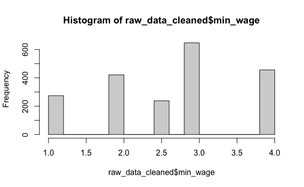

```
$breaks
 [1] 1.0 1.2 1.4 1.6 1.8 2.0 2.2 2.4 2.6 2.8 3.0 3.2 3.4 3.6 3.8 4.0

$counts
 [1] 207   0   0   0 344   0   0 220   0 679   0   0   0   0 586

$density
 [1] 0.5083497 0.0000000 0.0000000 0.0000000 0.8447937 0.0000000 0.0000000 0.5402750
 [9] 0.0000000 1.6674853 0.0000000 0.0000000 0.0000000 0.0000000 1.4390963

$mids
 [1] 1.1 1.3 1.5 1.7 1.9 2.1 2.3 2.5 2.7 2.9 3.1 3.3 3.5 3.7 3.9

$xname
[1] "raw_data_cleaned$free_calls"

$equidist
[1] TRUE

attr(,"class")
[1] "histogram"
```

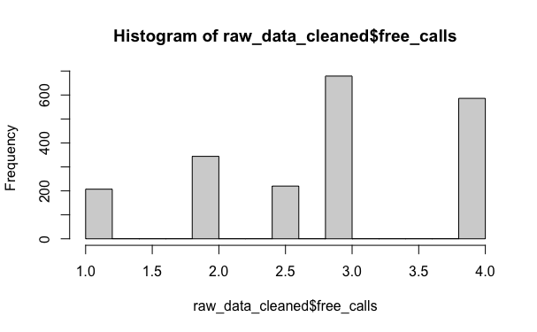

```
$breaks
 [1] 1.0 1.2 1.4 1.6 1.8 2.0 2.2 2.4 2.6 2.8 3.0 3.2 3.4 3.6 3.8 4.0

$counts
 [1] 108   0   0   0 187   0   0 164   0 797   0   0   0   0 779

$density
 [1] 0.2653563 0.0000000 0.0000000 0.0000000 0.4594595 0.0000000 0.0000000 0.4029484
 [9] 0.0000000 1.9582310 0.0000000 0.0000000 0.0000000 0.0000000 1.9140049

$mids
 [1] 1.1 1.3 1.5 1.7 1.9 2.1 2.3 2.5 2.7 2.9 3.1 3.3 3.5 3.7 3.9

$xname
[1] "raw_data_cleaned$ed_funds"

$equidist
[1] TRUE

attr(,"class")
[1] "histogram"
```

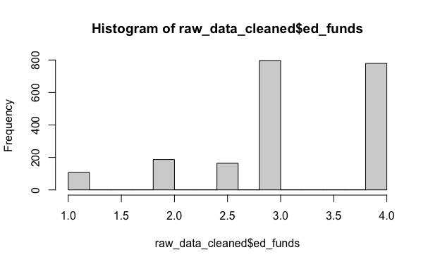

```
$breaks
 [1] 1.0 1.2 1.4 1.6 1.8 2.0 2.2 2.4 2.6 2.8 3.0 3.2 3.4 3.6 3.8 4.0

$counts
 [1] 146   0   0   0 287   0   0 376   0 816   0   0   0   0 410

$density
 [1] 0.3587224 0.0000000 0.0000000 0.0000000 0.7051597 0.0000000 0.0000000 0.9238329
 [9] 0.0000000 2.0049140 0.0000000 0.0000000 0.0000000 0.0000000 1.0073710

$mids
 [1] 1.1 1.3 1.5 1.7 1.9 2.1 2.3 2.5 2.7 2.9 3.1 3.3 3.5 3.7 3.9

$xname
[1] "raw_data_cleaned$alt_sentencing"

$equidist
[1] TRUE

attr(,"class")
[1] "histogram"
```

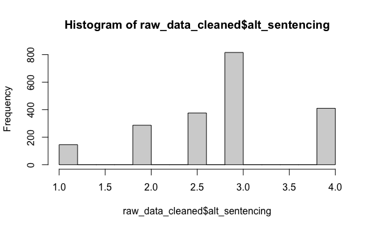

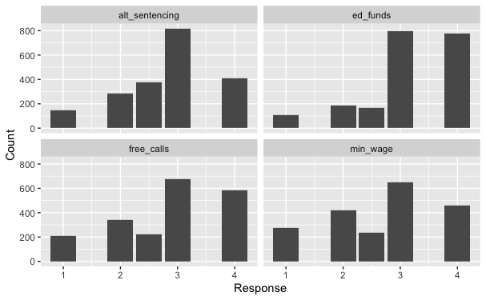

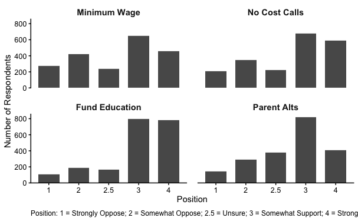